# rpick Notes

```r
#source("https://raw.githubusercontent.com/nimids/R-Projects/main/sourceGitHub.R")
source("source.R")
```

# Random Pick:

Picks n items from an urn filled with choices, with or without replacement.

- Usage
- Arguments
- Examples
- Plots

## Usage:

```r
rpick(
  n = 1,
  choices = c("A","B","C"),
  replace = TRUE,
  verbose = FALSE
)
```

## Arguments:

| n | number of draws |
| --- | --- |
| choices | vector of choices |
| replace | if TRUE, choices are put back before the next draw |
| verbose | if TRUE, forces rpick to print out it’s self |

## Examples:

Do one sample:

```r
n <- 10
choices <- c(1,1,1,2,2,3)
pickResult <- rpick(n, choices)
```

Print out the result:

```r
print(pickResult)
```

```
Pulled 10 things from an urn with {1, 1, 1, 2, 2, 3} inside, with replacement.

Result: 2, 3, 2, 2, 2, 1, 2, 1, 3, 1

Summary:
======  =====  ======
choice  numOf  propOf
======  =====  ======
     1      3     0.3
     2      5     0.5
     3      2     0.2
======  =====  ======
```

Look at raw values:

```r
value(pickResult)
```

```
$n
[1] 10

$choices
[1] 1 1 1 2 2 3

$replace
[1] TRUE

$result
 [1] 2 3 2 2 2 1 2 1 3 1

$numOf1
[1] 3

$numOf2
[1] 5

$numOf3
[1] 2
```

Do lots of one samples:

```r
samples <- 1000

samplesTable <- do(samples) * rpick(n, choices)

print(samplesTable)
```

| n | choices | replace | result | numOf1 | numOf2 | numOf3 | .row | .index |
| --- | --- | --- | --- | --- | --- | --- | --- | --- |
| 10 |  | TRUE |  | 5 | 4 | 1 | 1 | 1 |
| 10 |  | TRUE |  | 5 | 4 | 1 | 1 | 2 |
| 10 |  | TRUE |  | 5 | 4 | 1 | 1 | 3 |
| 10 |  | TRUE |  | 6 | 4 | 0 | 1 | 4 |
| 10 |  | TRUE |  | 6 | 3 | 1 | 1 | 5 |
| 10 |  | TRUE |  | 5 | 3 | 2 | 1 | 6 |
| 10 |  | TRUE |  | 5 | 2 | 3 | 1 | 7 |
| 10 |  | TRUE |  | 4 | 5 | 1 | 1 | 8 |
| 10 |  | TRUE |  | 1 | 4 | 5 | 1 | 9 |
| 10 |  | TRUE |  | 4 | 4 | 2 | 1 | 10 |

[output cut: 990 more lines]

We don’t need choices, replace and result, also do adds some extra columns we don’t need, .row and .index we could just ignore them. or we can use mutate to set the columns to NULL removing them.

```r
samplesTable %>%
  mutate(
    choices = NULL,
    replace = NULL,
    result = NULL,
    .row = NULL,
    .index = NULL
  ) ->
  samplesTable
print(samplesTable)
```

| n | numOf1 | numOf2 | numOf3 |
| --- | --- | --- | --- |
| 10 | 5 | 4 | 1 |
| 10 | 5 | 4 | 1 |
| 10 | 5 | 4 | 1 |
| 10 | 6 | 4 | 0 |
| 10 | 6 | 3 | 1 |
| 10 | 5 | 3 | 2 |
| 10 | 5 | 2 | 3 |
| 10 | 4 | 5 | 1 |
| 10 | 1 | 4 | 5 |
| 10 | 4 | 4 | 2 |

[output cut: 990 more lines]

Print out counts of each result:

```r
{
  cat("count numOf1:")
  print(table(samplesTable$numOf1))
  cat("count numOf2:")
  print(table(samplesTable$numOf2))
  cat("count numOf3:")
  print(table(samplesTable$numOf3))
}
```

```
count numOf1:
  0   1   2   3   4   5   6   7   8   9  10
  2  13  48 133 178 268 204  99  47   7   1
count numOf2:
  0   1   2   3   4   5   6   7   8   9
 18  81 182 245 246 148  53  20   5   2
count numOf3:
  0   1   2   3   4   5   6   7
165 324 296 149  49   8   8   1
```

## Plots:

### Count Bar Plot - Num of 1s:

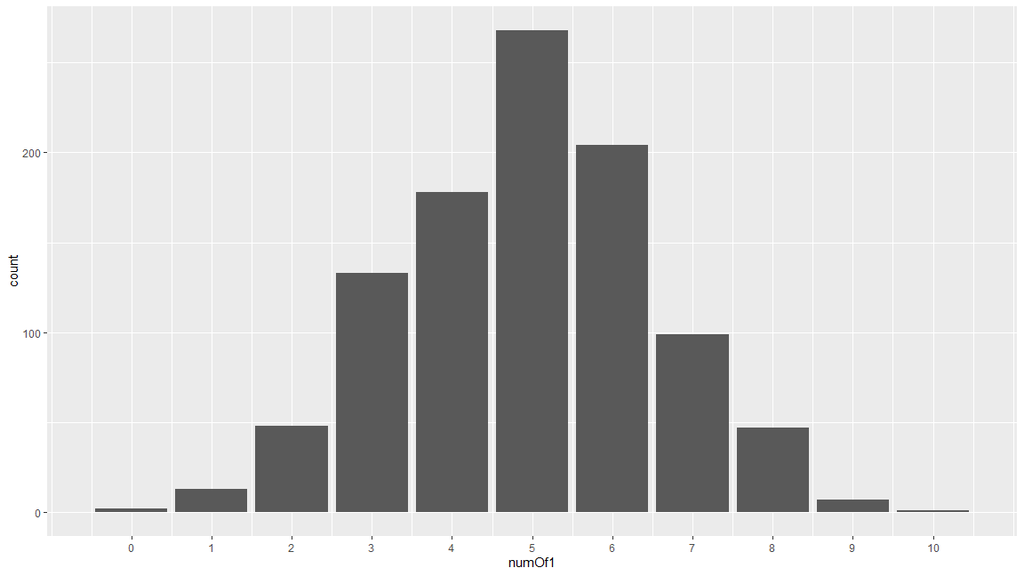

```r
print(
  samplesTable %>%
    gf_counts(~ numOf1) %>%
    gf_refine(scale_x_continuous(breaks = seq(0, n, length = n+1), limits = c(-0.5, n+0.5)))
)
```

### Count Bar Plot - Num of 2s:

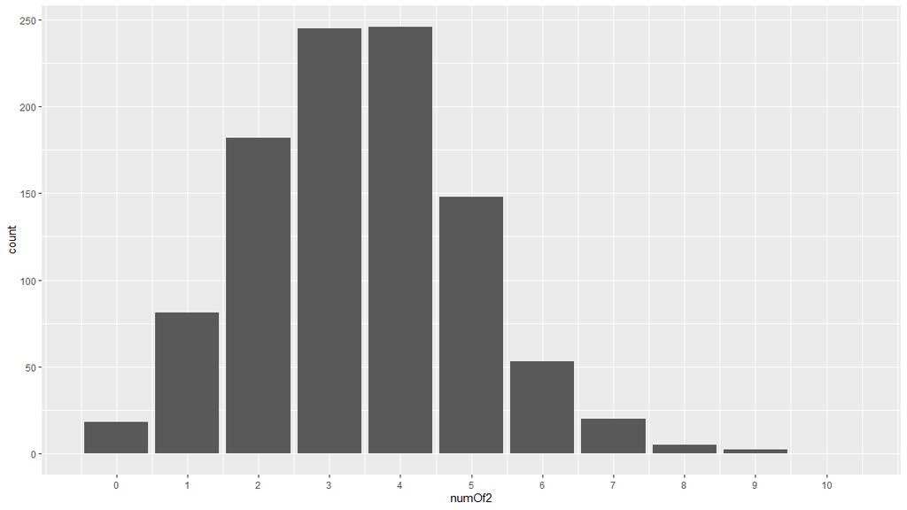

```r
print(
  samplesTable %>%
    gf_counts(~ numOf2) %>%
    gf_refine(scale_x_continuous(breaks = seq(0, n, length = n+1), limits = c(-0.5, n+0.5)))
)
```

### Count Bar Plot - Num of 3s:

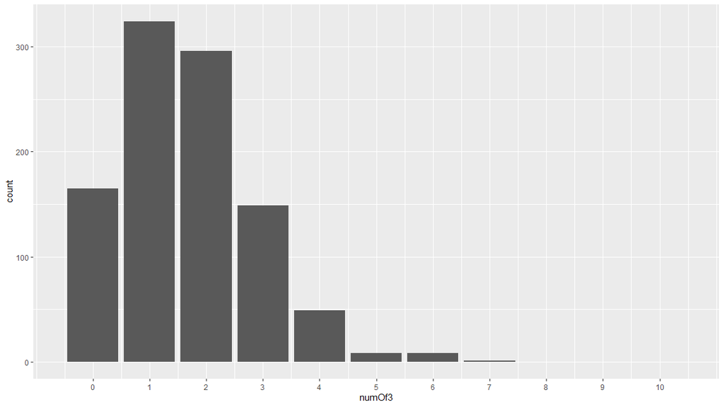

```r
print(
  samplesTable %>%
    gf_counts(~ numOf3) %>%
    gf_refine(scale_x_continuous(breaks = seq(0, n, length = n+1), limits = c(-0.5, n+0.5)))
)
```

### Percents Bar Blot - Num of 3s:

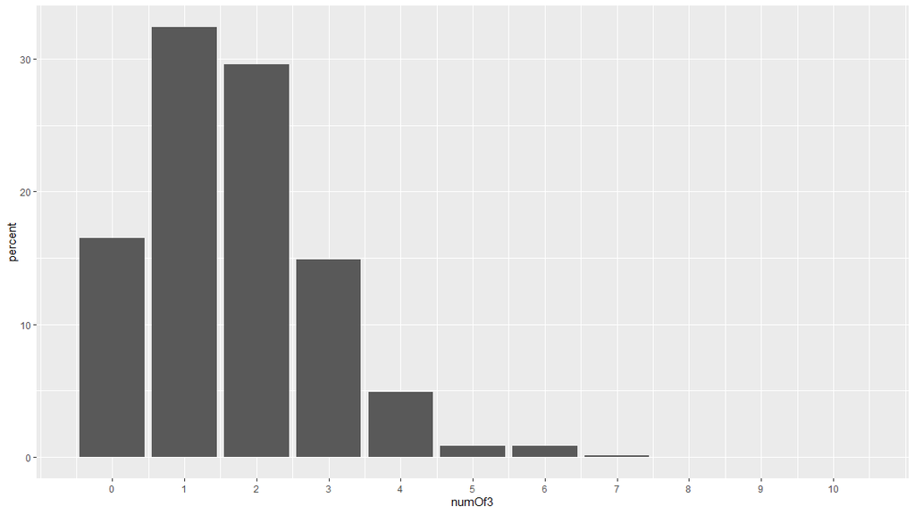

```r
print(
  samplesTable %>%
    gf_percents(~ numOf3) %>%
    gf_refine(scale_x_continuous(breaks = seq(0, n, length = n+1), limits = c(-0.5, n+0.5)))
)
```

### Proportion Bar Blot - Num of 3s:

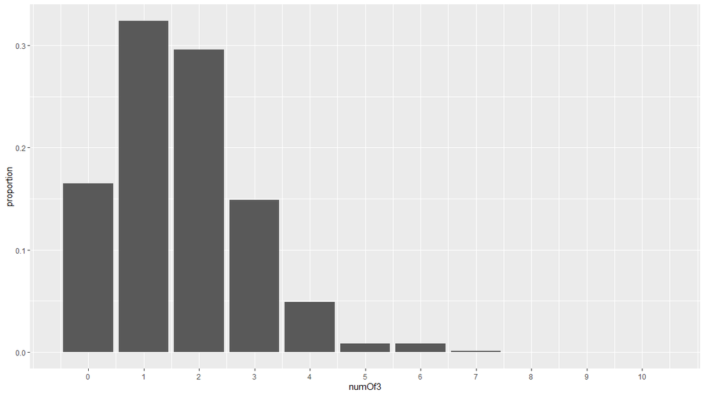

```r
print(
  samplesTable %>%
    gf_props(~ numOf3) %>%
    gf_refine(scale_x_continuous(breaks = seq(0, n, length = n+1), limits = c(-0.5, n+0.5)))
)
```

### Proportion Bar Blot - Proportions of 3s:

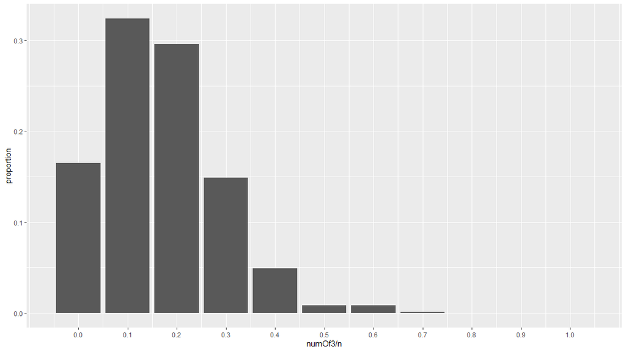

```r
print(
  samplesTable %>%
    gf_props(~ numOf3/n) %>%
    gf_refine(scale_x_continuous(breaks = seq(0, 1, length = n+1), limits = c(-0.5, n+0.5)/n))
)
```

If we wanted something like the number of 1s + number of 2s we can use mutate to build a new table.

```r
samplesTable %>%
  mutate(
    numOf1Plus2 = numOf1 + numOf2
  )
```

| n | numOf1 | numOf2 | numOf3 | numOf1Plus2 |
| --- | --- | --- | --- | --- |
| 10 | 5 | 4 | 1 | 9 |
| 10 | 5 | 4 | 1 | 9 |
| 10 | 5 | 4 | 1 | 9 |
| 10 | 6 | 4 | 0 | 10 |
| 10 | 6 | 3 | 1 | 9 |
| 10 | 5 | 3 | 2 | 8 |
| 10 | 5 | 2 | 3 | 7 |
| 10 | 4 | 5 | 1 | 9 |
| 10 | 1 | 4 | 5 | 5 |
| 10 | 4 | 4 | 2 | 8 |

[output cut: 990 more lines]

```r
NA
```

If we save that table we can use it to plot later or if we only plan on using it once we can just send it right to gf_props, gf_counts or gf_percents

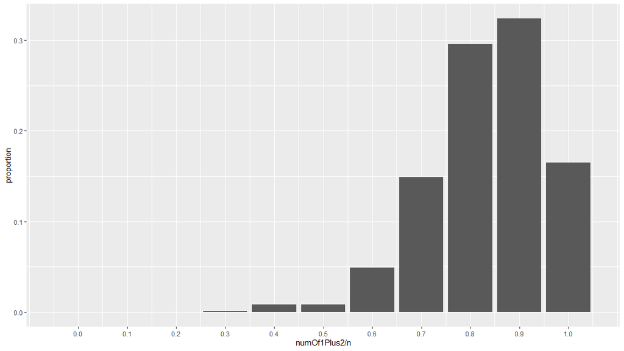

```r
samplesTable %>%
  mutate(
    numOf1Plus2 = numOf1 + numOf2
  ) %>%
  gf_props(~ numOf1Plus2/n) %>%
  gf_refine(scale_x_continuous(breaks = seq(0, 1, length = n+1), limits = c(-0.5, n+0.5)/n))
```

Or we can use the formula we give gf_props to do simple operations like adding, subtracting, multiplying and dividing.

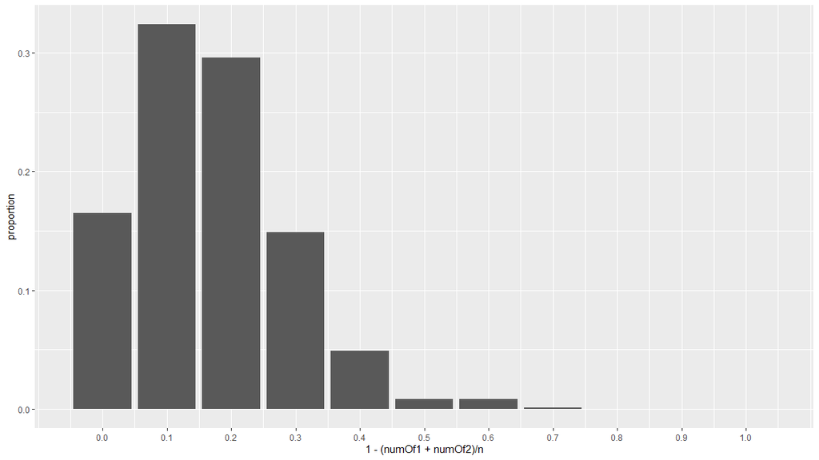

```r
samplesTable %>%
  gf_props(~ 1 - (numOf1 + numOf2)/n) %>%
  gf_refine(scale_x_continuous(breaks = seq(0, 1, length = n+1), limits = c(-0.5, n+0.5)/n))
```